# Session 1 — Time-to-Event Data

Censoring · survival and hazard · the Surv object · person-time and rates · Lab 1

Community Medicine Workshop

## Where we are

- Regression workshop: outcomes that are a **measurement** or a **yes/no**
- Today: the outcome is **how long until something happens**: death, relapse, recovery, default from treatment
- By the end you can:
  - say what **censoring** is, and why you cannot drop or average censored patients
  - define **survival**, **hazard** and **cumulative incidence**
  - build a `Surv` object and compute **person-time** and an **incidence rate**
  - describe **follow-up** correctly

## Our data: a synthetic TB cohort

- **600 adults** starting TB treatment, followed for up to **24 months**
- Outcome: **death**; `time_months` and `status` (1 = died, 0 = censored)
- Predictors: age, sex, HIV, diabetes, smoking, BMI, **MDR-TB**, smear status, **DOT** (supervised treatment)
- Invented, but built to behave like a real cohort

```r
tb |> select(id, age, hiv, mdr_tb, treatment, time_months, status) |> head(6)
```

```
# A tibble: 6 × 7
  id      age hiv      mdr_tb treatment         time_months status
  <chr> <dbl> <fct>    <fct>  <fct>                   <dbl>  <dbl>
1 TB001    43 Negative No     Self-administered         7.8      0
2 TB002    46 Negative No     DOT                      15.2      0
3 TB003    15 Negative No     DOT                      23.8      0
4 TB004    69 Negative No     Self-administered         2.6      0
5 TB005    73 Negative No     DOT                      20.7      0
6 TB006    42 Negative No     DOT                      19.9      0
```

```r
table(tb$status)
```

```
  0   1
487 113
```

# Topic 1 — Why survival analysis?

## Two problems with ordinary methods

- **Different follow-up:** a patient enrolled last month has had little time to die; one enrolled two years ago has had a lot. Comparing **proportions** who died ignores this
- **Censoring:** for many patients we **do not observe** the event

**Censored** = we know the patient was alive **at least until** their last contact, but not what happened afterwards.

| Why censored | Example |
| --- | --- |
| **Administrative** | still alive when the study ended |
| **Lost to follow-up** | moved away, stopped attending |
| **Competing event** | died of something else (a different question; see Session 5) |

## Censored patients still carry information

```r
tb |> slice(1:15) |> mutate(row = row_number(), outcome = ifelse(status == 1, "Died", "Censored")) |>
  ggplot(aes(y = reorder(id, -row))) + geom_segment(aes(x = 0, xend = time_months, yend = reorder(id, -row)), colour = "grey60") +
  geom_point(aes(x = time_months, colour = outcome, shape = outcome), size = 3) + scale_colour_manual(values = c(Died = col_red, Censored = col_blue)) +
  labs(x = "Months of follow-up", y = NULL, colour = NULL, shape = NULL)
```

- Each line is one patient; a **dot at the end** marks death or censoring
- A censored patient contributes **their time at risk** up to the last contact
- **Dropping** them wastes information and **biases** towards early deaths; **treating them as survivors forever** biases the other way

## Censored patients still carry information

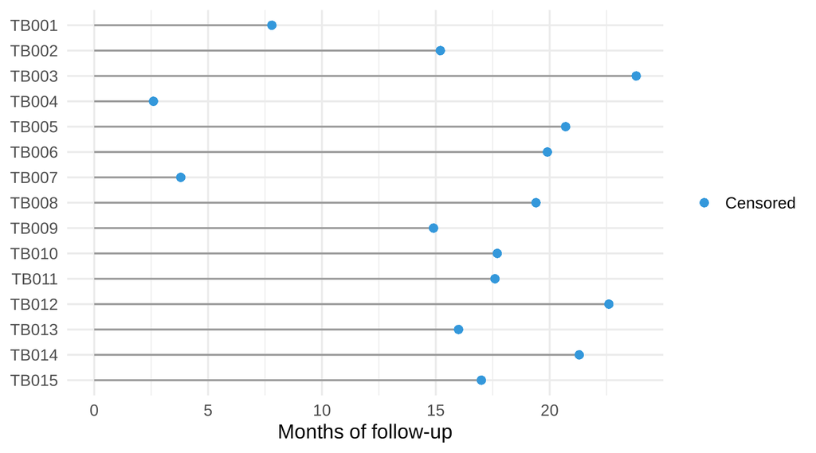

## The three quantities

| Quantity | Meaning |
| --- | --- |
| **Survival** S(t) | probability of being **alive beyond** time t |
| **Hazard** h(t) | the **instantaneous rate** of dying at t, among those still alive |
| **Cumulative incidence** | 1 − S(t): the probability of **having died by** t |

The **hazard** is a **rate** (events per person-time), not a probability. Cox regression (Session 4) models the hazard.

# Topic 2 — The Surv object

## Time and event together

```r
y <- Surv(tb$time_months, tb$status)
head(y, 10)
```

```
 [1]  7.8+ 15.2+ 23.8+  2.6+ 20.7+ 19.9+  3.8+ 19.4+ 14.9+ 17.7+
```

- `Surv(time, event)` pairs each follow-up time with its event indicator
- A **`+`** after a time marks a **censored** observation (still alive at least that long)
- Check the coding: **1 = event**, 0 = censored (factor and TRUE/FALSE also work, but check!)
- This object goes on the left of every survival model: `survfit(Surv(...) ~ group)`, `coxph(Surv(...) ~ x)`

## Do not summarise survival times with a mean

```r
c(mean_all = mean(tb$time_months), mean_among_deaths = mean(tb$time_months[tb$status == 1]))
```

```
         mean_all mean_among_deaths
        14.873500          5.780531
```

Neither number is a survival time. The first mixes deaths and censored times; the second looks only at those who died and **ignores everyone who survived**, so it is biased downwards.

# Topic 3 — Person-time and rates

## Incidence rate

```r
py <- sum(tb$time_months) / 12
c(deaths = sum(tb$status), person_years = round(py, 1), rate_per_100_py = round(sum(tb$status) / py * 100, 1))
```

```
         deaths    person_years rate_per_100_py
          113.0           743.7            15.2
```

- **Rate** = events / person-time at risk (here per 100 person-years)
- It uses **everyone’s** time, censored or not
- Valid if the hazard is roughly **constant**; Kaplan-Meier (Session 2) removes that assumption

## Describing follow-up honestly

```r
rkm <- survfit(Surv(time_months, 1 - status) ~ 1, data = tb)
c(median_raw_time = median(tb$time_months), median_followup_reverse_KM = unname(summary(rkm)$table["median"]))
```

```
           median_raw_time median_followup_reverse_KM
                      16.7                       18.1
```

The **reverse Kaplan-Meier** swaps the roles of event and censoring, so it asks “how long would a typical patient be followed *if they did not die*?”. The **median of the raw times** is pulled down by deaths and understates follow-up.

## Checklist before any analysis

1. Define **time zero** (start of treatment, diagnosis) and the **event** precisely
2. Check **time** is positive and in one unit; **status** is coded 0/1
3. Count **events** and **censored**; tabulate **why** censored
4. Report **median follow-up** (reverse KM), person-time and events

## 🔧 Switch to R — Lab 1

**File:** `survival-workshop/labs/lab1_data.R`

- `table()` of status and censoring reasons
- `Surv()`: the `+` marks censored times
- person-years, a rate per 100 person-years, reverse Kaplan-Meier

**Time:** 30 minutes · answer the Q questions in the comments

## Self-check quiz (1/5)

What does a patient who was alive at the last clinic visit (month 17) and then moved away contribute to the analysis?

- Nothing, since the outcome for this patient is unknown
- A death at month 17, since no later contact exists
- Their 17 months at risk, as a censored observation
- An observation that must be treated as survival forever

## Self-check quiz (2/5)

A TB cohort has 113 deaths among 600 patients. Why is ‘mortality = 113/600 = 19%’ a weak summary?

- The number of deaths is too small to be divided by 600 patients, so it is unstable
- Patients differ in follow-up, so a proportion mixes unequal time at risk
- Mortality is reported as a count and should not be given as a percentage
- The 19% ignores the fact that some of the patients in the cohort were female

## Self-check quiz (3/5)

In the output of a Surv object, 17.2+ means what?

- The patient died at 17.2 months
- The patient survived exactly 17.2 months in total
- The patient was censored at 17.2 months
- The patient had a second event after 17.2 months

## Self-check quiz (4/5)

What is the hazard in survival analysis?

- The probability of surviving beyond a given time point in the cohort
- The total number of deaths divided by the total number of patients
- The median time until the event occurs for half of the patients
- The instantaneous event rate among those still event-free

## Self-check quiz (5/5)

Why is the reverse Kaplan-Meier median a better description of follow-up than the median of the raw follow-up times?

- Deaths shorten raw times, so their median understates follow-up
- The reverse method removes all of the patients who were censored
- Raw follow-up times cannot be calculated when some patients died
- The reverse method gives the median survival time of the patients

## Score and take-home

**Your score:**

- **Censoring**: observed up to a time, then unknown; keep these patients
- Survival S(t), hazard h(t), cumulative incidence 1 − S(t)
- `Surv(time, event)`: a **+** means censored
- Use **person-time rates**, not a mean of follow-up times; report **median follow-up** by reverse KM

**Next:** Session 2: Kaplan-Meier curves